# EE049017: Hardware Systems Security

## Part One

1. Create a letter scatter histogram for each source message. Note that the message is divided into 16-letter blocks (aka STATE). The sotogram will collect the over the various statistics across the entire run (i.e. amount for the entire message)
2. We watched the article using AES, and after each round of AES and for the encrypted message at the end. Calculate the scatter plot of the letters throughout the entire message, some in the first section
3. Create one table that summarizes all the data and adds the average and standard deviation to each row

```python
plaintext_binary = list(plaintext.encode())
plaintext_freq =  {i : plaintext_binary.count(i) for i in range(0,254)}
plt.bar( plaintext_freq.keys(), plaintext_freq.values(), 1.0, color='g')
plt.show()
```

[output not shown]

```python
import binascii
spec_enc_text = [""]*10

for i in range(0, len(plaintext), 16):
    ciper = aes_lib_rand.encrypt_by_stage(int(plaintext[i:i+16].encode().hex(),base=16))
    for j,c in enumerate(ciper):
        spec_enc_text[j] += ('{:x}'.format(c)).zfill(32)
```

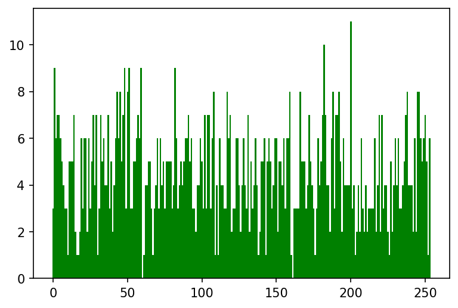

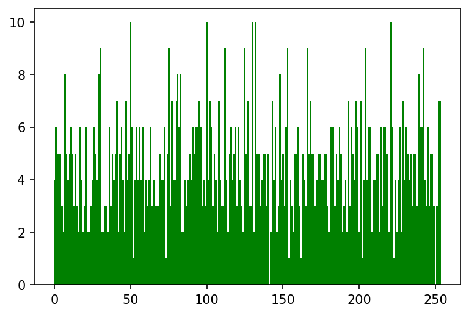

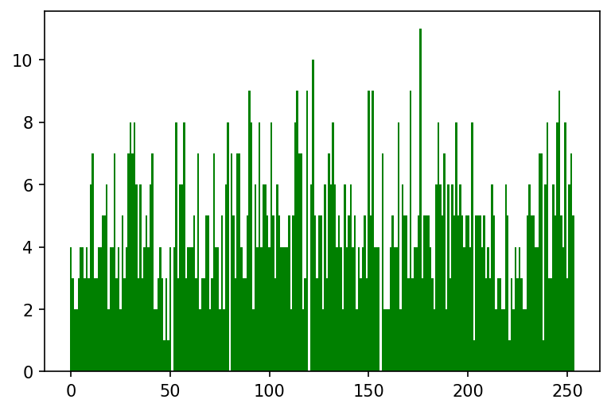

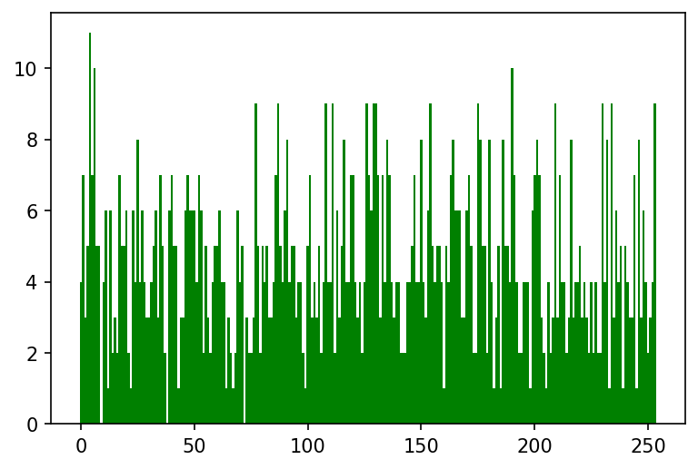

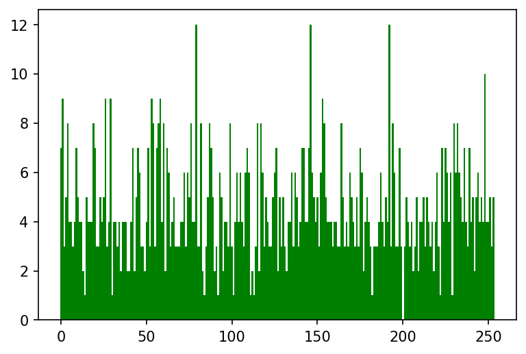

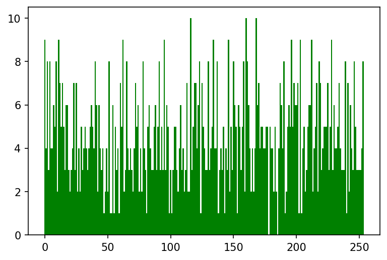

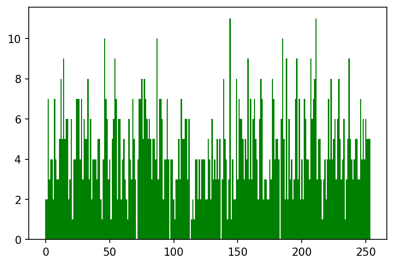

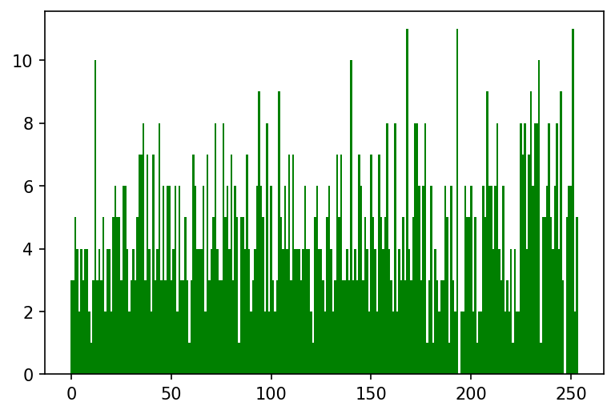

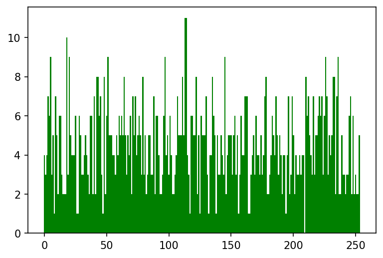

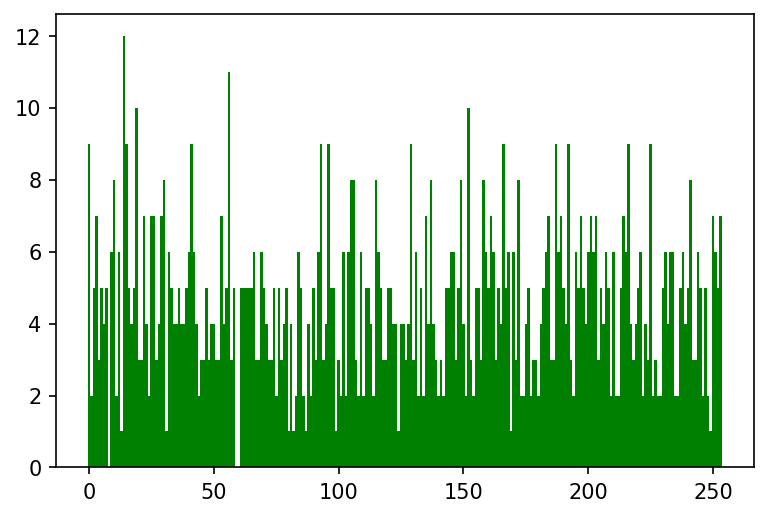

```python
cipertext_freq = []
for s in spec_enc_text:
    val = {i :  list(bytes.fromhex(s)).count(i) for i in range(0,254)}
    cipertext_freq.append(val)
    plt.bar( val.keys(), val.values(), 1.0, color='g')
    plt.show()
```

```python
columns=[]
final_freq = [plaintext_freq]  + cipertext_freq
histo_result = np.zeros((len(final_freq),34))

for row,s in enumerate(final_freq):
    current_values = list(s.values())
    for col in range(0,254,8):
        histo_result[row][col//8] = sum(current_values[col:col+8])
    histo_result[row][-1] = np.std(current_values)
    histo_result[row][-2] = np.mean(current_values)

display(pd.DataFrame(histo_result, columns=[f"{col}-{col+7}" for col in range(0,254,8)]+["STD","MEAN"]))
```

[output not shown]

11 rows × 34 columns

### HW1 - part 3 - Seq

```python
import sys, random,binascii,AES_Continuous,jupyter_utils
import matplotlib.pyplot as plt
import numpy as np
import pandas as pd
from IPython.display import Markdown, display,HTML
%matplotlib inline
plt.rcParams['figure.dpi'] = 150
```

We would like to test these principles when operating AES in different situations Note that for the purpose of the exercise, we will allow ourselves a number of mitigating assumptions which will be detailed below

To do this, take the following text which was published today on the BBC website

```python
with open("plaintext.txt","r") as f:
    plaintext = f.read()
print("Total Length:",len(plaintext))
display(Markdown(f'\n"**_{plaintext}_**"'))
```

```
Total Length: 1168
```

"*From the Pope to Greta Thunberg, there are growing calls for the crime of "ecocide" to be recognised in international criminal law - but could such a law ever work? In December 2019, at the International Criminal Court in the Hague, Vanuatu's ambassador to the European Union made a radical suggestion: make the destruction of the environment a crime. Vanuatu is a small island state in the South Pacific, a nation severely threatened by rising sea levels. Climate change is an imminent and existential crisis in the country, yet the actions that have caused rising temperatures - such as burning fossil fuels - have almost entirely taken place elsewhere, to serve other nations, with the blessing of state governments. Small island states like Vanuatu have long tried to persuade large powerful nations to voluntarily reduce their emissions, but change has been slow - so ambassador John Licht suggested that it might be time to change the law itself. An amendment to a treaty known as the Rome Statute, which established the International Criminal Court, could criminalise acts that amount to ecocide, he said, arguing "this radical idea merits serious discussion".*"

And we will try to encrypt the message, using an encryption key **"R is a Short key"**

```python
key = "R is a Short key"
key = key.encode().hex()
print(f"'R is a Short key':\n 0x{key}")
aes_lib_seq = AES_Continuous.AES(int(key,base=16))
```

```
'R is a Short key':
 0x5220697320612053686f7274206b6579
```

## Part One

1. Create a letter scatter histogram for each source message. Note that the message is divided into 16-letter blocks (aka STATE). The sotogram will collect the over the various statistics across the entire run (i.e. amount for the entire message)
2. We watched the article using AES, and after each round of AES and for the encrypted message at the end. Calculate the scatter plot of the letters throughout the entire message, some in the first section
3. Create one table that summarizes all the data and adds the average and standard deviation to each row

```python
plaintext_binary = list(plaintext.encode())
plaintext_freq =  {i : plaintext_binary.count(i) for i in range(0,254)}
plt.bar( plaintext_freq.keys(), plaintext_freq.values(), 1.0, color='g')
plt.show()
```

[output not shown]

```python
import binascii
spec_enc_text = [""]*10

for i in range(0, len(plaintext), 16):
    ciper = aes_lib_seq.encrypt_by_stage(int(plaintext[i:i+16].encode().hex(),base=16))
    for j,c in enumerate(ciper):
        spec_enc_text[j] += ('{:x}'.format(c)).zfill(32)
```

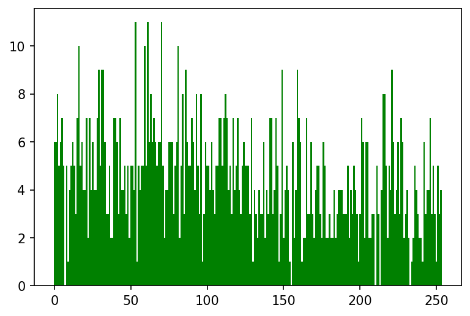

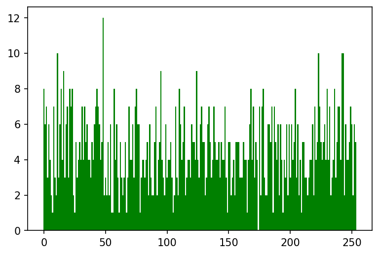

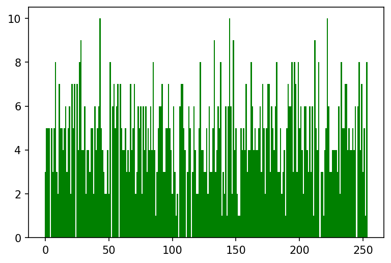

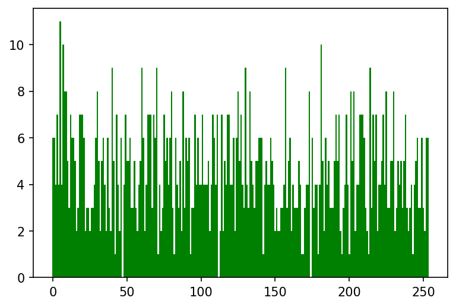

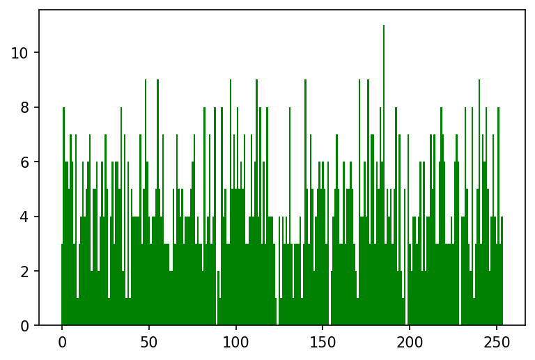

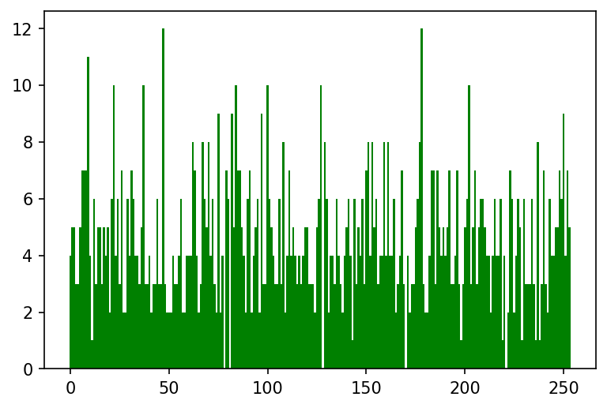

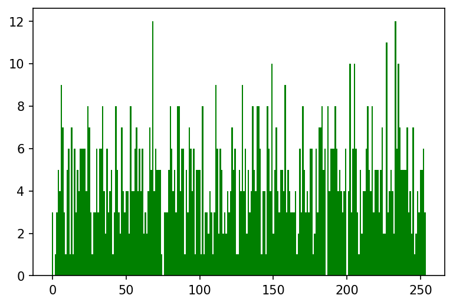

[figure not shown]

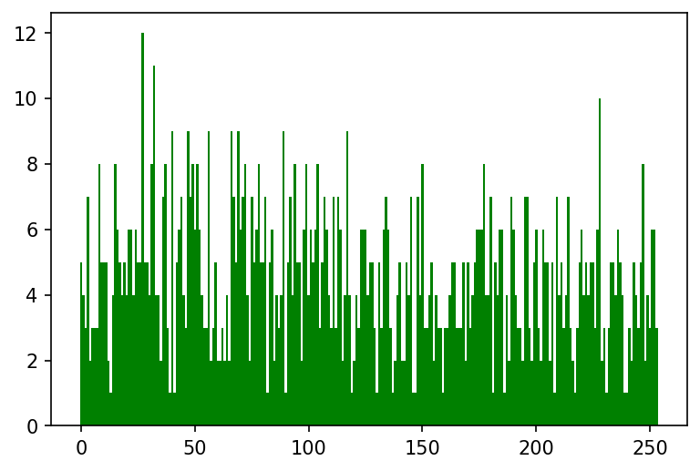

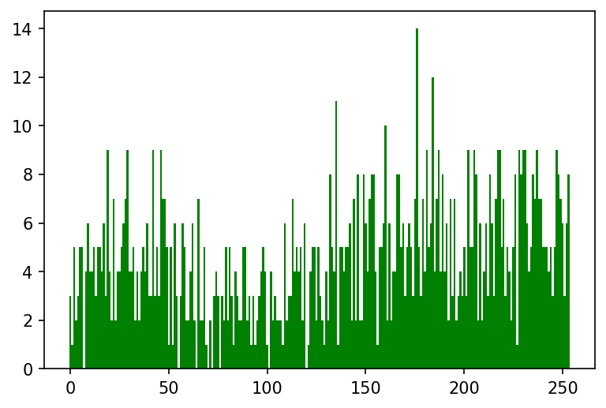

```python
cipertext_freq = []
for s in spec_enc_text:
    val = {i :  list(bytes.fromhex(s)).count(i) for i in range(0,254)}
    cipertext_freq.append(val)
    plt.bar( val.keys(), val.values(), 1.0, color='g')
    plt.show()
```

```python
columns=[]
final_freq = [plaintext_freq]  + cipertext_freq
histo_result = np.zeros((len(final_freq),34))

for row,s in enumerate(final_freq):
    current_values = list(s.values())
    for col in range(0,254,8):
        histo_result[row][col//8] = sum(current_values[col:col+8])
    histo_result[row][-1] = np.std(current_values)
    histo_result[row][-2] = np.mean(current_values)

pd.DataFrame(histo_result, columns=[f"{col}-{col+7}" for col in range(0,254,8)]+["STD","MEAN"])
```

[output not shown]

11 rows × 34 columns

# HW1 - part 4

```python
import sys, random,binascii,AES,jupyter_utils,random
import matplotlib.pyplot as plt
import numpy as np
import pandas as pd
from IPython.display import Markdown, display,HTML
%matplotlib inline
plt.rcParams['figure.dpi'] = 150
```

This section will focus on the Diffusion principle and examine the extent to which a change in input or internal states affects the end result. The runs in the strain part will be performed on a single input block (16 characters)

```python
plaintext = "From the Pope to"
print("Total Length:",len(plaintext))
display(Markdown(f'\n"**_{plaintext}_**"'))
```

```
Total Length: 16
```

"*From the Pope to*"

And we will try to encrypt the message, using an encryption key **"R is a Short key"**

```python
key = "R is a Short key"
key = key.encode().hex()
print(f"'R is a Short key':\n 0x{key}")
aes_lib = AES.AES(int(key,base=16))
```

```
'R is a Short key':
 0x5220697320612053686f7274206b6579
```

## Question 4:

1. Run the AES algorithm, and save the intermediate results after each round (including the final result)
2. Randomly select a bit in the login message and change it from 0 -> 1 or 1-> 0 accordingly Repeat (1) and calculate how many bits changed their value as a result of the change of the single bit in each round, and the encrypted message (relative to the same situation when no errors were injected)
3. Repeat the experiment 5 times when each time you change one bit in relation to the message in (1) at the end of the runs, present a table

```python
def run_aes_stages(plaintext):
    spec_enc_text = [""]*10
    for i in range(0, len(plaintext), 16):
        ciper = aes_lib.encrypt_by_stage(int(plaintext[i:i+16].encode().hex(),base=16))
        for j,c in enumerate(ciper):
            spec_enc_text[j] += ('{:x}'.format(c)).zfill(32)
    return spec_enc_text
spec_enc_text = run_aes_stages(plaintext)
display(spec_enc_text)
```

```
['cb95e6a2a56a602164f8bdc338622f85',
 'cbf42cb3f27bbb6266e1e7abbc87199e',
 '5953b07e2a304dc27be50e6355176310',
 '203d5627e023761e3d86efd4ace38e38',
 'b874b055f6f6fc733e8c7952dbf7ea9c',
 '1dba47880ed16f3c72d966c2526347cc',
 '737bf4f4317604824733b3b13695b2cf',
 'd0d5082d7e23c65c2e2cd9304833f9f6',
 '54d92855bb1e7c8075c0eb813950e85d',
 '793ec12a27911757630e1fd3c4affd06']
```

For stage II and on, we wants' to create a convertion function

```python
def tobits(s):
    result = []
    for c in s:
        bits = bin(ord(c))[2:]
        bits = '00000000'[len(bits):] + bits
        result.extend([int(b) for b in bits])
    return result

def frombits(bits):
    chars = []
    for b in range(len(bits) // 8 ):
        byte = bits[b*8:(b+1)*8]
        chars.append(chr(int(''.join([str(bit) for bit in byte]), 2)))
    return ''.join(chars)

def count_flips_to_convert(a, b):

    diff = a ^ b

    # count number of ones in diff
    count = 0
    while diff:
        diff &= (diff - 1)
        count += 1
    return count
```

```python
def flip_plaintext(plaintext):
    bitflip_p = tobits(plaintext)
    place = random.choice(range(len(bitflip_p)))
    bitflip_p[place] = int(1 - bitflip_p[place])
    bitflip_plaintext = frombits(bitflip_p)
    return bitflip_plaintext,place
bitflip_plaintext,place = flip_plaintext(plaintext)
print("The bit which was chosen to be replaced: ", place)
print("Result:",bitflip_plaintext)
```

```
The bit which was chosen to be replaced:  84
Result: From the Pgpe to
```

```python
bitflip_spec_enc_text = run_aes_stages(bitflip_plaintext)
display(bitflip_spec_enc_text)
```

```
['3689075fa56a602164f8bdc338622f85',
 'ffee369d078ebf932d3c71e030869413',
 '420575864268b0954142c48e54fdd4db',
 'f2e910056962f56de0f60ce978c6e11a',
 'cf8fb4eb8a7dc9e968d83e414287a3a0',
 '2c0f567ce17e68dafdff92ecb51b77f9',
 '2079799e7348b9b23e000eab1c980209',
 '53e34bc4e144691793d9d92bcdc2413a',
 'f0fcd54bbf775050bcde28a772b98bd9',
 'd5b91c53c536b1189b0b284d962abe56']
```

```python
def calulate_diffrence(textlist,flip_textlist):
    diff = []
    for i in range(len(flip_textlist)):
        p =  int(textlist[i],base=16)
        c =  int(flip_textlist[i],base=16)
        diff.append(count_flips_to_convert(p,c))
    return diff
diff = calulate_diffrence(bitflip_spec_enc_text,spec_enc_text)
display(diff)
```

```
[21, 61, 71, 60, 65, 69, 59, 68, 58, 65]
```

```python
table_result = np.zeros((6,len(bitflip_spec_enc_text)))

for i in range(5):
    bfp,place = flip_plaintext(plaintext)
    bfp_stage = run_aes_stages(bfp)
    table_result[i] = calulate_diffrence(bfp_stage,spec_enc_text)
```

```python
table_result[5] = np.mean(table_result[:5], axis = 0)
display(pd.DataFrame(table_result, columns=[f"Round {col+1}" for col in range(len(bitflip_spec_enc_text))]))
```

[output not shown]

# HW1 - part 5

```python
import sys, random,binascii,AES,jupyter_utils,random
import matplotlib.pyplot as plt
import numpy as np
import pandas as pd
from IPython.display import Markdown, display,HTML
%matplotlib inline
plt.rcParams['figure.dpi'] = 150
```

This section will focus on the Diffusion principle and examine the extent to which a change in input or internal states affects the end result. The runs in the strain part will be performed on a single input block (16 characters)

```python
plaintext = "From the Pope to"
print("Total Length:",len(plaintext))
display(Markdown(f'\n"**_{plaintext}_**"'))
```

```
Total Length: 16
```

"*From the Pope to*"

And we will try to encrypt the message, using an encryption key **"R is a Short key"**

```python
key = "R is a Short key"
key = key.encode().hex()
print(f"'R is a Short key':\n 0x{key}")
aes_lib = AES.AES(int(key,base=16))
```

```
'R is a Short key':
 0x5220697320612053686f7274206b6579
```

# Question 5:

```python
spec_enc_text = [""]*11
for i in range(-1,10):
    ciper = aes_lib.encrypt_by_stage(int(plaintext.encode().hex(),base=16), injection_itr=i)
    spec_enc_text[i+1] = ciper

spec_enc_diff = [""]*10

for i in range(0,10):
    spec_enc_diff[i] = [bin(spec_enc_text[i+1][j] ^ spec_enc_text[0][j]).count("1") for j in range(len(spec_enc_text[0]))]

display(pd.DataFrame(spec_enc_diff))

# table shows diff from non injected text
# row = injection round [0,...,10]
# col = intermediate stage [1,...,10]
```

|  | 0 | 1 | 2 | 3 | 4 | 5 | 6 | 7 | 8 | 9 |
| --- | --- | --- | --- | --- | --- | --- | --- | --- | --- | --- |
| 0 | 18 | 57 | 57 | 61 | 61 | 58 | 67 | 65 | 71 | 59 |
| 1 | 1 | 11 | 57 | 66 | 69 | 64 | 63 | 73 | 57 | 67 |
| 2 | 0 | 1 | 19 | 66 | 59 | 68 | 60 | 69 | 66 | 65 |
| 3 | 0 | 0 | 1 | 23 | 79 | 69 | 66 | 64 | 75 | 65 |
| 4 | 0 | 0 | 0 | 1 | 16 | 67 | 68 | 66 | 65 | 57 |
| 5 | 0 | 0 | 0 | 0 | 1 | 17 | 54 | 60 | 64 | 76 |
| 6 | 0 | 0 | 0 | 0 | 0 | 1 | 18 | 69 | 70 | 62 |
| 7 | 0 | 0 | 0 | 0 | 0 | 0 | 1 | 22 | 61 | 66 |
| 8 | 0 | 0 | 0 | 0 | 0 | 0 | 0 | 1 | 10 | 18 |
| 9 | 0 | 0 | 0 | 0 | 0 | 0 | 0 | 0 | 1 | 4 |

# HW1 - part 6

```python
import sys, random,binascii,AES,jupyter_utils,random
import matplotlib.pyplot as plt
import numpy as np
import pandas as pd
from IPython.display import Markdown, display,HTML
%matplotlib inline
plt.rcParams['figure.dpi'] = 150
```

This section will focus on the Diffusion principle and examine the extent to which a change in input or internal states affects the end result. The runs in the strain part will be performed on a single input block (16 characters)

```python
plaintext = "From the Pope to"
print("Total Length:",len(plaintext))
display(Markdown(f'\n"**_{plaintext}_**"'))
```

```
Total Length: 16
```

"*From the Pope to*"

```python
def tobits(s):
    result = []
    for c in s:
        bits = bin(ord(c))[2:]
        bits = '00000000'[len(bits):] + bits
        result.extend([int(b) for b in bits])
    return result

def frombits(bits):
    chars = []
    for b in range(len(bits) // 8 ):
        byte = bits[b*8:(b+1)*8]
        chars.append(chr(int(''.join([str(bit) for bit in byte]), 2)))
    return ''.join(chars)

def count_flips_to_convert(a, b):

    diff = a ^ b

    # count number of ones in diff
    count = 0
    while diff:
        diff &= (diff - 1)
        count += 1
    return count

def flip_plaintext(plaintext):
    bitflip_p = tobits(plaintext)
    place = random.choice(range(len(bitflip_p)))
    bitflip_p[place] = int(1 - bitflip_p[place])
    bitflip_plaintext = frombits(bitflip_p)
    return bitflip_plaintext,place
bitflip_plaintext,place = flip_plaintext(plaintext)
print("The bit which was chosen to be replaced: ", place)
print("Result:",bitflip_plaintext)
```

```
The bit which was chosen to be replaced:  110
Result: From the Pope"to
```

And we will try to encrypt the message, using an encryption key **"R is a Short key"**

```python
key = "R is a Short key"
print(f"'R is a Short key':\n 0x{key.encode().hex()}")

keys = 7*[key]
place = 7*[""]
aes_lib = 7*[""]

aes_lib[0] = AES.AES(int(keys[0].encode().hex(),base=16))
print("0st key wasn't flipped")
for i in range(6):
    keys[i+1],place[i+1] = flip_plaintext(key)
    print(str(i+1) + "st key was flipped at place " + str(place[i+1]))
    aes_lib[i+1] = AES.AES(int(keys[i+1].encode().hex(),base=16))
```

```
'R is a Short key':
 0x5220697320612053686f7274206b6579
0st key wasn't flipped
1st key was flipped at place 76
2st key was flipped at place 58
3st key was flipped at place 31
4st key was flipped at place 55
5st key was flipped at place 34
6st key was flipped at place 101
```

## Question 6:

1. Run the AES algorithm, and save the intermediate results after each round (including the final result)
2. Randomly select a bit in the key and change it from 0 -> 1 or 1-> 0 accordingly Repeat (1) and calculate how many bits changed their value as a result of the change of the single bit in each round, and the encrypted message (relative to the same situation when no errors were injected)
3. Repeat the experiment 5 or 6 times when each time you change one bit in relation to the message in (1) at the end of the runs, present a table

```python
def run_aes_stages(plaintext, key_num):
    spec_enc_text = [""]*10
    for i in range(0, len(plaintext), 16):
        ciper = aes_lib[key_num].encrypt_by_stage(int(plaintext[i:i+16].encode().hex(),base=16))
        for j,c in enumerate(ciper):
            spec_enc_text[j] += ('{:x}'.format(c)).zfill(32)
    return spec_enc_text
spec_enc_text = run_aes_stages(plaintext, 0)
display(spec_enc_text)
```

```
['cb95e6a2a56a602164f8bdc338622f85',
 'cbf42cb3f27bbb6266e1e7abbc87199e',
 '5953b07e2a304dc27be50e6355176310',
 '203d5627e023761e3d86efd4ace38e38',
 'b874b055f6f6fc733e8c7952dbf7ea9c',
 '1dba47880ed16f3c72d966c2526347cc',
 '737bf4f4317604824733b3b13695b2cf',
 'd0d5082d7e23c65c2e2cd9304833f9f6',
 '54d92855bb1e7c8075c0eb813950e85d',
 '793ec12a27911757630e1fd3c4affd06']
```

```python
print("Displaying output with another key")
bitflip_spec_enc_text = run_aes_stages(plaintext, 1)
display(bitflip_spec_enc_text)
```

```
Displaying output with another key
```

```
['cb95e6a28faf8fce64f0bdc3386a2f85',
 '150257c8078f0330a0d4d5ef4c79443d',
 'cb3fe5e533c8a0b4e9b7c10da2cd0230',
 'cb8a3334f040f4dc3bc1ab619e270baa',
 'fe8119a88e15aeb86cf62b573f96ceaf',
 '1b41fa229eec4587291a80e4202ff4ff',
 'b3260284807cf48689f402d1504431f0',
 '63a613f7f63a9f15a3c8d6ba71f3a960',
 'f12adadf880b0bb65bcefaeb36d8eb64',
 'fe8480730fa0e0358e4ab2d29a7f08e3']
```

```python
def calulate_diffrence(textlist,flip_textlist):
    diff = []
    for i in range(len(flip_textlist)):
        p =  int(textlist[i],base=16)
        c =  int(flip_textlist[i],base=16)
        diff.append(count_flips_to_convert(p,c))
    return diff
diff = calulate_diffrence(bitflip_spec_enc_text,spec_enc_text)
display(diff)
```

```
[23, 75, 68, 54, 63, 68, 60, 58, 60, 63]
```

```python
table_result = np.zeros((7,len(bitflip_spec_enc_text)))

for i in range(6):
    bfp_stage = run_aes_stages(plaintext, key_num=1+i)
    table_result[i] = calulate_diffrence(bfp_stage,spec_enc_text)
```

```python
table_result[6] = np.mean(table_result[:6], axis = 0)
display(pd.DataFrame(table_result, columns=[f"Round {col+1}" for col in range(len(bitflip_spec_enc_text))]))
```

|  | Round 1 | Round 2 | Round 3 | Round 4 | Round 5 | Round 6 | Round 7 | Round 8 | Round 9 | Round 10 |
| --- | --- | --- | --- | --- | --- | --- | --- | --- | --- | --- |
| 0 | 23.000000 | 75.000000 | 68.000000 | 54.000000 | 63.0 | 68.0 | 60.000000 | 58.0 | 60.000000 | 63.000000 |
| 1 | 13.000000 | 68.000000 | 58.000000 | 58.000000 | 65.0 | 54.0 | 63.000000 | 61.0 | 69.000000 | 59.000000 |
| 2 | 22.000000 | 62.000000 | 62.000000 | 67.000000 | 66.0 | 63.0 | 69.000000 | 61.0 | 61.000000 | 66.000000 |
| 3 | 21.000000 | 66.000000 | 65.000000 | 63.000000 | 69.0 | 67.0 | 66.000000 | 60.0 | 65.000000 | 58.000000 |
| 4 | 19.000000 | 63.000000 | 58.000000 | 71.000000 | 68.0 | 60.0 | 57.000000 | 64.0 | 68.000000 | 61.000000 |
| 5 | 27.000000 | 60.000000 | 54.000000 | 67.000000 | 56.0 | 69.0 | 50.000000 | 59.0 | 66.000000 | 61.000000 |
| 6 | 20.833333 | 65.666667 | 60.833333 | 63.333333 | 64.5 | 63.5 | 60.833333 | 60.5 | 64.833333 | 61.333333 |

# Summary and Conclusions

In the first three questions, we have seen that all the histograms look entirely different from the original since the first iteration. Thus, we can say that these findings support the property of confusion. In the last three questions, we can see that the flipping of one bit in the plaintext or the key changes the result dramatically. However, depending on the flipping location and the iteration number, we have seen that there is a large variance in the number of flipped bits in the following text state.